# Renny_Oyelahan_Project_03

**Background and Context**

AllLife Bank is a US bank that has a growing customer base. The majority of these customers are liability customers (depositors) with varying sizes of deposits. The number of customers who are also borrowers (asset customers) is quite small, and the bank is interested in expanding this base rapidly to bring in more loan business and in the process, earn more through the interest on loans. In particular, the management wants to explore ways of converting its liability customers to personal loan customers (while retaining them as depositors).

A campaign that the bank ran last year for liability customers showed a healthy conversion rate of over 9% success. This has encouraged the retail marketing department to devise campaigns with better target marketing to increase the success ratio.

You as a Data scientist at AllLife bank have to build a model that will help the marketing department to identify the potential customers who have a higher probability of purchasing the loan.

**Objective**

1) To predict whether a liability customer will buy a personal loan or not. 2) Which variables are most significant. 3) Which segment of customers should be targeted more.

### **Key Questions:**

1. How do the different attributes such as income, credit card spending, mortgage, experience etc... predict whether a liability customer will buy a personal loan or not.
2. Which of the differen attributes are more significant in predicting whether or not a liability customer will buy a personal loan.
3. What insights & recommendations can be derived that will help the bank target the right segment of customers?

Data Dictionary

- ID: Customer ID
- Age: Customer’s age in completed years
- Experience: #years of professional experience
- Income: Annual income of the customer (in thousand dollars)
- ZIP Code: Home Address ZIP code.
- Family: the Family size of the customer
- CCAvg: Average spending on credit cards per month (in thousand dollars)
- Education: Education Level. 1: Undergrad; 2: Graduate;3: Advanced/Professional
- Mortgage: Value of house mortgage if any. (in thousand dollars)
- Personal_Loan: Did this customer accept the personal loan offered in the last campaign?
- Securities_Account: Does the customer have securities account with the bank?
- CD_Account: Does the customer have a certificate of deposit (CD) account with the bank?
- Online: Do customers use internet banking facilities?
- CreditCard: Does the customer use a credit card issued by any other Bank (excluding All life Bank)?

```python
from google.colab import drive
drive.mount('/content/drive')
```

### Import necessary libraries

```python
# Library to suppress warnings or deprecation notes
import warnings

warnings.filterwarnings("ignore")

# Libraries to help with reading and manipulating data

from sklearn import metrics
import pandas as pd
import numpy as np

# Library to split data
from sklearn.model_selection import train_test_split

# To build model for prediction

from sklearn.linear_model import LogisticRegression


# libaries to help with data visualization
import matplotlib.pyplot as plt
import seaborn as sns

# Library to split data
from sklearn.model_selection import train_test_split

# Removes the limit for the number of displayed columns
pd.set_option("display.max_columns", None)
# Sets the limit for the number of displayed rows
pd.set_option("display.max_rows", 200)

# Libraries to build decision tree classifier
from sklearn.tree import DecisionTreeClassifier
from sklearn import tree

# To tune different models
from sklearn.model_selection import GridSearchCV

# To get diferent metric scores
from sklearn.metrics import (
    f1_score,
    accuracy_score,
    recall_score,
    precision_score,
    precision_recall_curve,
    roc_auc_score,
    roc_curve,
    confusion_matrix,
    ConfusionMatrixDisplay,
    make_scorer,
)
```

### Import dataset

```python
df = pd.read_csv("/content/drive/MyDrive/Colab_Notebooks/Logistics Regression/Project 03/Loan_Modelling.csv")
```

**View the first and last 10 rows of the Dataset**

```python
df.head(10)
```

|  | ID | Age | Experience | Income | ZIPCode | Family | CCAvg | Education | Mortgage | Personal_Loan | Securities_Account | CD_Account | Online | CreditCard |
| --- | --- | --- | --- | --- | --- | --- | --- | --- | --- | --- | --- | --- | --- | --- |
| 0 | 1 | 25 | 1 | 49 | 91107 | 4 | 1.6 | 1 | 0 | 0 | 1 | 0 | 0 | 0 |
| 1 | 2 | 45 | 19 | 34 | 90089 | 3 | 1.5 | 1 | 0 | 0 | 1 | 0 | 0 | 0 |
| 2 | 3 | 39 | 15 | 11 | 94720 | 1 | 1.0 | 1 | 0 | 0 | 0 | 0 | 0 | 0 |
| 3 | 4 | 35 | 9 | 100 | 94112 | 1 | 2.7 | 2 | 0 | 0 | 0 | 0 | 0 | 0 |
| 4 | 5 | 35 | 8 | 45 | 91330 | 4 | 1.0 | 2 | 0 | 0 | 0 | 0 | 0 | 1 |
| 5 | 6 | 37 | 13 | 29 | 92121 | 4 | 0.4 | 2 | 155 | 0 | 0 | 0 | 1 | 0 |
| 6 | 7 | 53 | 27 | 72 | 91711 | 2 | 1.5 | 2 | 0 | 0 | 0 | 0 | 1 | 0 |
| 7 | 8 | 50 | 24 | 22 | 93943 | 1 | 0.3 | 3 | 0 | 0 | 0 | 0 | 0 | 1 |
| 8 | 9 | 35 | 10 | 81 | 90089 | 3 | 0.6 | 2 | 104 | 0 | 0 | 0 | 1 | 0 |
| 9 | 10 | 34 | 9 | 180 | 93023 | 1 | 8.9 | 3 | 0 | 1 | 0 | 0 | 0 | 0 |

```python
df.tail(10)
```

|  | ID | Age | Experience | Income | ZIPCode | Family | CCAvg | Education | Mortgage | Personal_Loan | Securities_Account | CD_Account | Online | CreditCard |
| --- | --- | --- | --- | --- | --- | --- | --- | --- | --- | --- | --- | --- | --- | --- |
| 4990 | 4991 | 55 | 25 | 58 | 95023 | 4 | 2.00 | 3 | 219 | 0 | 0 | 0 | 0 | 1 |
| 4991 | 4992 | 51 | 25 | 92 | 91330 | 1 | 1.90 | 2 | 100 | 0 | 0 | 0 | 0 | 1 |
| 4992 | 4993 | 30 | 5 | 13 | 90037 | 4 | 0.50 | 3 | 0 | 0 | 0 | 0 | 0 | 0 |
| 4993 | 4994 | 45 | 21 | 218 | 91801 | 2 | 6.67 | 1 | 0 | 0 | 0 | 0 | 1 | 0 |
| 4994 | 4995 | 64 | 40 | 75 | 94588 | 3 | 2.00 | 3 | 0 | 0 | 0 | 0 | 1 | 0 |
| 4995 | 4996 | 29 | 3 | 40 | 92697 | 1 | 1.90 | 3 | 0 | 0 | 0 | 0 | 1 | 0 |
| 4996 | 4997 | 30 | 4 | 15 | 92037 | 4 | 0.40 | 1 | 85 | 0 | 0 | 0 | 1 | 0 |
| 4997 | 4998 | 63 | 39 | 24 | 93023 | 2 | 0.30 | 3 | 0 | 0 | 0 | 0 | 0 | 0 |
| 4998 | 4999 | 65 | 40 | 49 | 90034 | 3 | 0.50 | 2 | 0 | 0 | 0 | 0 | 1 | 0 |
| 4999 | 5000 | 28 | 4 | 83 | 92612 | 3 | 0.80 | 1 | 0 | 0 | 0 | 0 | 1 | 1 |

There are no obvious missing values from the head and tail informationn

**Checking the names of the columns in the Dataset**

```python
print(df.columns)
```

```
Index(['ID', 'Age', 'Experience', 'Income', 'ZIPCode', 'Family', 'CCAvg',
       'Education', 'Mortgage', 'Personal_Loan', 'Securities_Account',
       'CD_Account', 'Online', 'CreditCard'],
      dtype='object')
```

**Checking the shape of the Dataset**

```python
print(f"There are {df.shape[0]} rows and {df.shape[1]} columns.")  # f-string
```

```
There are 5000 rows and 14 columns.
```

**Checking the data types of the columns in the Dataset**

```python
df.info()
```

```
<class 'pandas.core.frame.DataFrame'>
RangeIndex: 5000 entries, 0 to 4999
Data columns (total 14 columns):
 #   Column              Non-Null Count  Dtype
---  ------              --------------  -----
 0   ID                  5000 non-null   int64
 1   Age                 5000 non-null   int64
 2   Experience          5000 non-null   int64
 3   Income              5000 non-null   int64
 4   ZIPCode             5000 non-null   int64
 5   Family              5000 non-null   int64
 6   CCAvg               5000 non-null   float64
 7   Education           5000 non-null   int64
 8   Mortgage            5000 non-null   int64
 9   Personal_Loan       5000 non-null   int64
 10  Securities_Account  5000 non-null   int64
 11  CD_Account          5000 non-null   int64
 12  Online              5000 non-null   int64
 13  CreditCard          5000 non-null   int64
dtypes: float64(1), int64(13)
memory usage: 547.0 KB
```

- There are all numerical columns in the data.
- We observe that all columns have 5000 entries, which is equal to the number of rows which indicates there are no missing values in this Dataset.

**Let's double-check for null values in the Dataset**

```python
df.isnull().sum()
```

```
ID                    0
Age                   0
Experience            0
Income                0
ZIPCode               0
Family                0
CCAvg                 0
Education             0
Mortgage              0
Personal_Loan         0
Securities_Account    0
CD_Account            0
Online                0
CreditCard            0
dtype: int64
```

We have confirmed there are no null values in the dataset.

**Checking for duplicate entries in the Dataset**

```python
df.duplicated().sum()
```

```
0
```

There are no duplicate entries in the dataset.

**Let's drop ID**

```python
df.drop(['ID'],axis=1,inplace=True)
```

**Checking the statistical summary of the Dataset**

```python
df.describe(include="all").T
```

|  | count | mean | std | min | 25% | 50% | 75% | max |
| --- | --- | --- | --- | --- | --- | --- | --- | --- |
| Age | 5000.0 | 45.338400 | 11.463166 | 23.0 | 35.0 | 45.0 | 55.0 | 67.0 |
| Experience | 5000.0 | 20.104600 | 11.467954 | -3.0 | 10.0 | 20.0 | 30.0 | 43.0 |
| Income | 5000.0 | 73.774200 | 46.033729 | 8.0 | 39.0 | 64.0 | 98.0 | 224.0 |
| ZIPCode | 5000.0 | 93169.257000 | 1759.455086 | 90005.0 | 91911.0 | 93437.0 | 94608.0 | 96651.0 |
| Family | 5000.0 | 2.396400 | 1.147663 | 1.0 | 1.0 | 2.0 | 3.0 | 4.0 |
| CCAvg | 5000.0 | 1.937938 | 1.747659 | 0.0 | 0.7 | 1.5 | 2.5 | 10.0 |
| Education | 5000.0 | 1.881000 | 0.839869 | 1.0 | 1.0 | 2.0 | 3.0 | 3.0 |
| Mortgage | 5000.0 | 56.498800 | 101.713802 | 0.0 | 0.0 | 0.0 | 101.0 | 635.0 |
| Personal_Loan | 5000.0 | 0.096000 | 0.294621 | 0.0 | 0.0 | 0.0 | 0.0 | 1.0 |
| Securities_Account | 5000.0 | 0.104400 | 0.305809 | 0.0 | 0.0 | 0.0 | 0.0 | 1.0 |
| CD_Account | 5000.0 | 0.060400 | 0.238250 | 0.0 | 0.0 | 0.0 | 0.0 | 1.0 |
| Online | 5000.0 | 0.596800 | 0.490589 | 0.0 | 0.0 | 1.0 | 1.0 | 1.0 |
| CreditCard | 5000.0 | 0.294000 | 0.455637 | 0.0 | 0.0 | 0.0 | 1.0 | 1.0 |

### Univariate Analysis

**Let's check the distribution for numerical columns.**

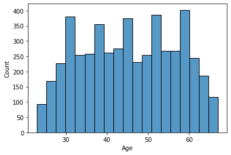

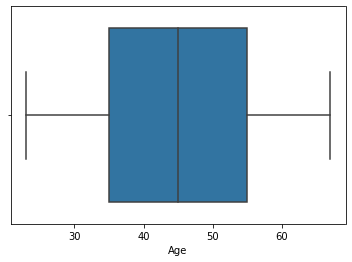

```python
# checking the age of the customers
sns.histplot(data=df, x="Age")
plt.show();
sns.boxplot(data=df, x="Age")
plt.show();
```

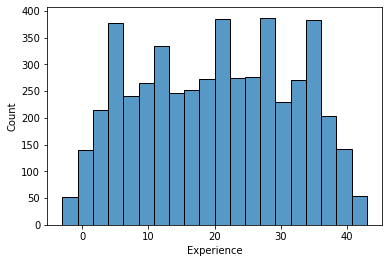

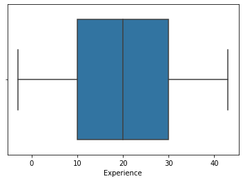

```python
# checking how many years of professional experience of the customers
sns.histplot(data=df, x="Experience")
plt.show();
sns.boxplot(data=df, x="Experience")
plt.show();
```

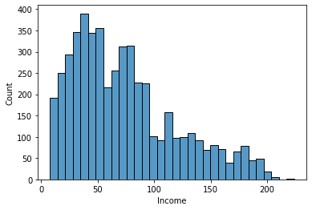

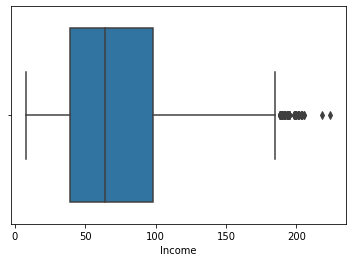

```python
# checking the annual income of the customers
sns.histplot(data=df, x="Income")
plt.show();
sns.boxplot(data=df, x="Income")
plt.show();
```

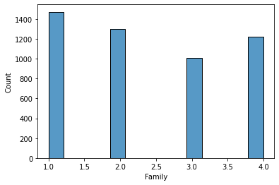

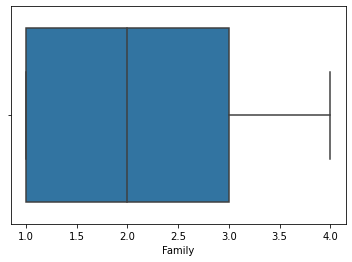

```python
# checking the family size of the customers
sns.histplot(data=df, x="Family")
plt.show();
sns.boxplot(data=df, x="Family")
plt.show();
```

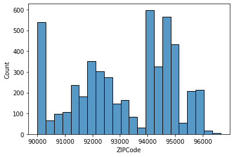

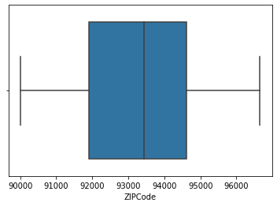

```python
# checking zipcode where they live
sns.histplot(data=df, x="ZIPCode")
plt.show();
sns.boxplot(data=df, x="ZIPCode")
plt.show();
```

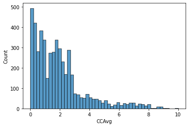

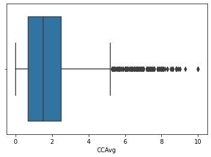

```python
# checking average credit card spending per month
sns.histplot(data=df, x="CCAvg")
plt.show();
sns.boxplot(data=df, x="CCAvg")
plt.show();
```

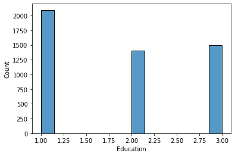

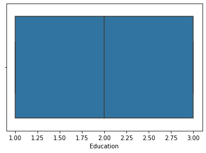

```python
# checking how educated the customers are
sns.histplot(data=df, x="Education")
plt.show();
sns.boxplot(data=df, x="Education")
plt.show();
```

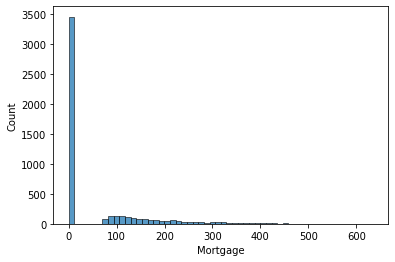

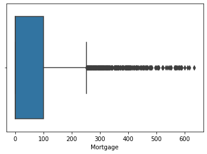

```python
# checking how many have mortgages
sns.histplot(data=df, x="Mortgage")
plt.show();
sns.boxplot(data=df, x="Mortgage")
plt.show();
```

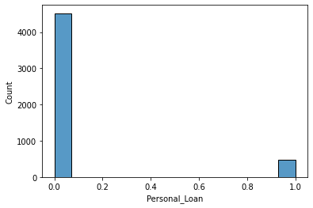

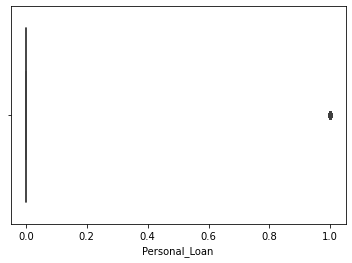

```python
# checking how many have Personal Loans from the last campaign
sns.histplot(data=df, x="Personal_Loan")
plt.show();
sns.boxplot(data=df, x="Personal_Loan")
plt.show();
```

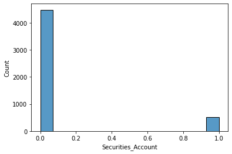

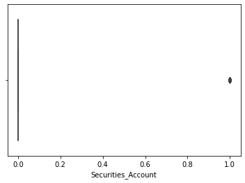

```python
# checking how many have securities_Account
sns.histplot(data=df, x="Securities_Account")
plt.show();
sns.boxplot(data=df, x="Securities_Account")
plt.show();
```

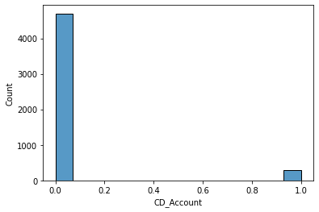

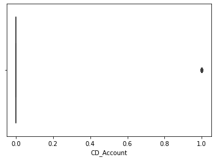

```python
# checking how many have CD_Account
sns.histplot(data=df, x="CD_Account")
plt.show();
sns.boxplot(data=df, x="CD_Account")
plt.show();
```

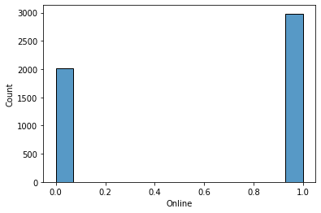

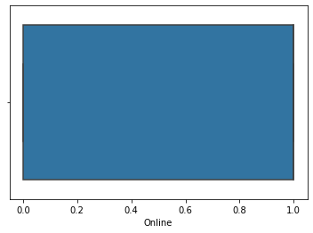

```python
# checking how many use online banking
sns.histplot(data=df, x="Online")
plt.show();
sns.boxplot(data=df, x="Online")
plt.show();
```

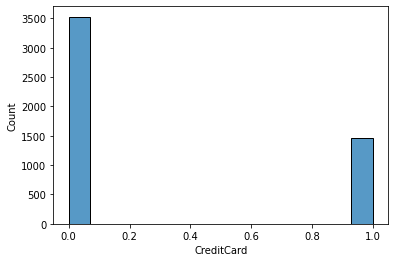

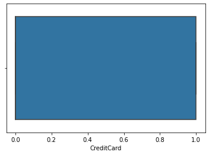

```python
# checking the CreditCard info of the customers
sns.histplot(data=df, x="CreditCard")
plt.show();
sns.boxplot(data=df, x="CreditCard")
plt.show();
```

### Multivariate and Bivariate Analysis

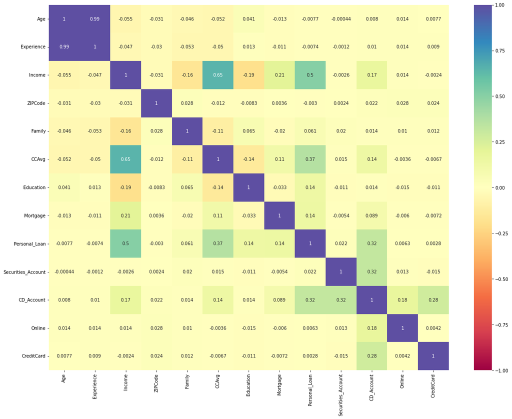

```python
plt.figure(figsize=(20,15))
sns.heatmap(df.corr(),annot=True,cmap='Spectral',vmin=-1,vmax=1)
plt.show()
```

**Observations**

- `Personal_Loan` has a positive correlation with `Income`, `CCAvg`, and `CD-Account`.
- `Income` has a strong positive correlation with average credit card spending and personal loan.
- `Income` also has a somewhat moderate positive correlation with `Mortgage` and `CD_account`.
- `Income` has a weak positive or negative correlation with the remaining attributes.
- `Age` and `Experience` have the highest positve correlation with each other
- `CD_account` has a somewhat moderate positive correlation with `Personal_loan`, `Securities` and credit cards from other banks.
- The remaining attributes have either a weak positive correlation or negative correlation with each other.

**Analysis of correlated variables that are noteworthy**

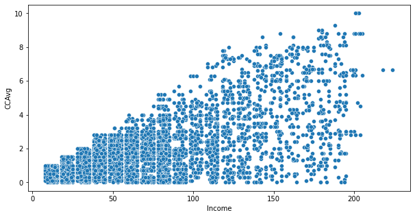

```python
plt.figure(figsize=(10,5))
sns.scatterplot(data=df,x='Income',y='CCAvg')
plt.show()
```

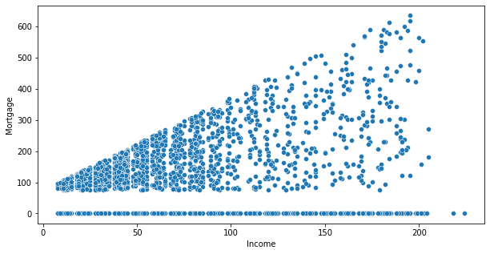

```python
plt.figure(figsize=(10,5))
sns.scatterplot(data=df,x='Income',y='Mortgage')
plt.show()
```

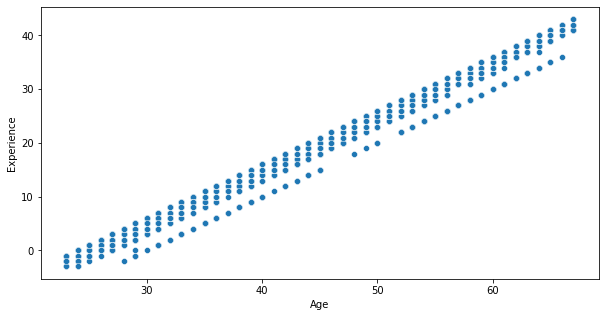

```python
plt.figure(figsize=(10,5))
sns.scatterplot(data=df,x='Age',y='Experience')
plt.show()
```

**Observations**

- Income has a positive correlation with credit card spending and mortgage.
- Age has an almost positive correlation with experience.

```python
# copying data to another varaible to avoid any changes to original data
pd.DataFrame = df.copy()
```

```python
# Let's see how the different types of income relate to the features with positive correlation
pd.DataFrame["Income"] = pd.cut(
    pd.DataFrame["Income"],
    [-np.inf, 50.0, 100.0, 150.0, 200.0, np.inf],
    labels=["Income_Level1", "Income_Level2", "Income_Level3", "Income_Level4", "Income_Level5"],
)

pd.DataFrame["Income"].value_counts()
```

```
Income_Level1    1914
Income_Level2    1874
Income_Level3     770
Income_Level4     426
Income_Level5      16
Name: Income, dtype: int64
```

### Let's compare `CCAvg` versus `Income`

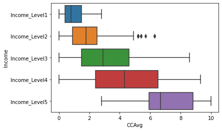

```python
sns.boxplot(data=pd.DataFrame,x='CCAvg',y='Income')
plt.show()
```

**Observations**